# Optimization of sampling strata with the SamplingStrata package

# Initial solution with kmeans clustering of atomic strata

In order to speed up the convergence towards the optimal solution, an initial one can be given as a “suggestion” to ‘optimizeStrata’ function. The function *KmeansSolution* produces this initial solution by clustering atomic strata considering the values of the means of all the target variables Y.

Also, the optimal number of clusters is determined inside each domain. If the default value for nstrata is used, then the number of aggregate strata is optimized by varying the number of cluster from 2 to number of atomic strata in each domain, divided by 2. Otherwise, it is possible to indicate a fixed number of aggregate strata to be obtained.

Other parameters are:

- *minnumstrat*: the minimum number of units to be allocated in each stratum(default is 2);
- *maxcluster*: the maximum number of clusters to be considered in the execution of kmeans algorithm;
- *showPlot*: if TRUE, allows to visualise the optimization.

For any given number of clusters, the correspondent aggregation of atomic strata is considered as input to the function ‘bethel’. The number of clusters for which the value of the sample size necessary to fulfil precision constraints is the minimum one, is retained as the optimal one.

The overall solution is obtained by concatenating optimal clusters obtained in domains. The result is a dataframe with two columns: the first indicates the clusters, the second the domains:

```r
solutionKmeans <- KmeansSolution(swissstrata,
                                   swisserrors,
                                   nstrata=NA,
                                   minnumstrat=2,
                                   maxclusters=NA,
                                   showPlot=FALSE)
```

```
#>
#> -----------------
#>  Kmeans solution
#> -----------------
#>  *** Domain:  1  ***
#>  Number of strata:  9
#>  Sample size     :  18
#>  *** Domain:  2  ***
#>  Number of strata:  9
#>  Sample size     :  17
#>  *** Domain:  3  ***
#>  Number of strata:  7
#>  Sample size     :  13
#>  *** Domain:  4  ***
#>  Number of strata:  6
#>  Sample size     :  10
#>  *** Domain:  5  ***
#>  Number of strata:  7
#>  Sample size     :  13
#>  *** Domain:  6  ***
#>  Number of strata:  7
#>  Sample size     :  13
#>  *** Domain:  7  ***
#>  Number of strata:  8
#>  Sample size     :  16
```

```r
head(solutionKmeans)
```

```
#>   suggestions domainvalue
#> 1           3           1
#> 2           3           1
#> 3           3           1
#> 4           3           1
#> 5           3           1
#> 6           3           1
```

This solution can be given as argument to the parameter *suggestion* in the *optimizeStrata* function.

Suppose we want to optimize the stratification of domain 3 by making use of the initial solution given by the kmeans algorithm in that domain:

```
#>
#> ---------------------------------------------
#> Optimal stratification with Genetic Algorithm
#> ---------------------------------------------
#>  *** Parameters ***
#> ---------------------------
#> Domain:  3
#> Maximum number of strata:  61
#> Minimum number of units per stratum:  2
#> Take-all strata (TRUE/FALSE):  FALSE
#> number of sampling strata :  61
#> Number of target variables:  4
#> Number of domains:  1
#> Number of GA iterations:  50
#> Dimension of GA population:  20
#> Mutation chance in GA generation:  NA
#> Elitism rate in GA generation:  0.2
#> Chance to add strata to maximum:  0
#> Allocation with real numbers instead of integers:  TRUE
#> Suggestion:  6 5 5 5 5 1 5 5 5 5 5 5 4 4 4 4 4 4 4 4 7 6 6 6 6 6 6 6 6 2 2 2 2 2 2 2 2 2 3 3 3 3 3 3 3 3 3 1 1 1 1 1 1 1 1 1 1 1 1 1 1
#>  *** Sample cost:  12.09278
#>  *** Number of strata:  6
```

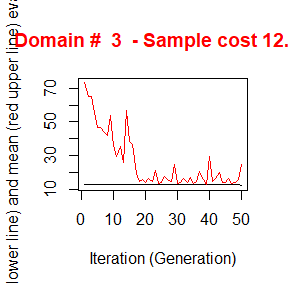

```
#>
#>  *** Sample size :  12
#>  *** Number of strata :  6
#> ---------------------------
sum(ceiling(solution_dom3$aggr_strata$SOLUZ))
#> [1] 13
```

```r
solution_dom3 <- optimizeStrata(
    errors = swisserrors,
    strata = swissstrata,
    alldomains = FALSE,
    dom = 3,
    suggestions = solutionKmeans[solutionKmeans$domainvalue == 3,],
    parallel = FALSE,
    showPlot = FALSE)
```

thus obtaining a much more conventient solution than the one without the kmeans suggestion, with the same number of iterations.

# Adjustment of the final sampling size

After the optimization step, the final sample size is the result of the allocation of units in final strata. This allocation is such that the precision constraints are expected to be satisfied. Actually, three possible situations may occur:

- the resulting sample size is acceptable;
- the resulting sample size is to high, it is not affordable with respect to the available budget;
- the resulting sample size is too low, the available budget permits to increase the number of units.

In the first case, no action is required. In the second case, it is necessary to reduce the number of units, by equally applying the same reduction rate in each stratum. In the third case, we could either to set more tight precision constraints, or proceed to increase the sample size by applying the same increase rate in each stratum. This increase/reduction process is iterative, as by applying the same rate we could find that in some strata there are not enough units to increase or to reduce. The function *adjustSize* permits to obtain the desired final sample size. Let us suppose that the obtained sample size is not affordable. We can reduce it by executing the following code:

```r
adjustedStrata <- adjustSize(size=200,strata=solution$aggr_strata,cens=NULL)
```

```
#>
#>  196
#>  196
#>  Final adjusted size:  196
```

```r
sum(adjustedStrata$SOLUZ)
```

```
#> [1] 196
```

Instead, if we want to increase the size because the budget allows to do this, then this is the code:

```r
adjustedStrata <- adjustSize(size=400,strata=solution$aggr_strata,cens=NULL)
```

```
#>
#>  381
#>  385
#>  385
#>  Final adjusted size:  385
```

```r
sum(adjustedStrata$SOLUZ)
```

```
#> [1] 385
```

The difference between the desired sample size and the actual adjusted size depends on the number of strata in the optimized solution. Consider that the adjustment is performed in each stratum by taking into account the relative difference between the current sample size and the desired one: this produces an allocation that is expressed by a real number, that must be rounded. The higher the number of strata, the higher the impact of the rounding in all strata on the final adjusted sample size.

# Analysis of results

This function has two purposes:

1. instrumental to the processing of the sampling frame (attribution of the labels of the optimized strata to the population units);
2. analysis of the aggregation of the atomic strata obtained in the optimized solution.

The function *updateStrata* assigns the labels of the new strata to the initial one in the dataframe *strata*, and produces:

- a new dataframe named *newstrata* containing all the information in the *strata* dataframe, plus the labels of the new optimized strata;
- a table, contained in the dataset *strata_aggregation.txt*, showing in which way each optimized stratum aggregates the auxiliary variables X’s.

The function is invoked in this way:

```r
newstrata <- updateStrata(swissstrata,
                          solution,
                          writeFiles = TRUE)
```

Now, the atomic strata are associated to the aggregate strata defined in the optimal solution, by means of the variable *LABEL*. If we want to analyse in detail the new structure of the stratification, we can look at the *strata_aggregation.txt* file:

```r
strata_aggregation <- read.delim("strata_aggregation.txt")
head(strata_aggregation)
```

```
#>   DOM1 AGGR_STRATUM X1 X2 X3 X4 X5 X6
#> 1    1            1  1  1  1  1  1  1
#> 2    1            1  1  2  1  3  1  1
#> 3    1            1  2  2  1  2  1  1
#> 4    1            1  4  3  2  2  2  1
#> 5    1            2  1  1  1  1  1  2
#> 6    1            2  4  1  1  1  1  2
```

In this structure, for each aggregate stratum the values of the X’s variables in each contributing atomic stratum are reported. It is then possible to understand the meaning of each aggregate stratum produced by the optimization.

# Updating the frame and selecting the sample

Once the optimal stratification has been obtained, to be operational we need to accomplish the following two steps:

- to update the frame units with new stratum labels (combination of the new values of the auxiliary variables X’s);
- to select the sample from the frame.

As for the first, we execute the following command:

```r
framenew <- updateFrame(swissframe, newstrata, writeFiles=TRUE)
```

The function *updateFrame* receives as arguments the indication of the dataframe in which the frame information is memorised, and of the dataframe produced by the execution of the *updateStrata* function. The execution of this function produces a dataframe *framenew*, and also a file (named *framenew.txt*) with the labels of the new strata produced by the optimisation step. The allocation of units is contained in the *SOLUZ* column of the dataset *outstrata.txt*. At this point it is possible to select the sample from the new version of the frame:

```r
sample <- selectSample(framenew, solution$aggr_strata, writeFiles=TRUE)
```

```
#>
#> *** Sample has been drawn successfully ***
#>  204  units have been selected from  75  strata
#>
#> ==> There have been  10  take-all strata
#> from which have been selected  21 units
```

that produces two .csv files:

- *sample.csv* containing the units of the frame that have been selected, together with the weight that has been calculated for each one of them;
- *sample.chk.csv* containing information on the selection: for each stratum, the number of units in the population, the planned sample, the number of selected units, the sum of their weights that must equalise the number of units in the population.

The *selectSample* operates by drawing a simple random sampling in each stratum.

A variant of this function is *selectSampleSystematic*. The only difference is in the method used for selecting units in each strata, that is by executing the following steps:

1. a selection interval is determined by considering the inverse of the sampling rate in the stratum;
2. a starting point is determined by selecting a value in this interval;
3. the selection proceeds by selecting as first unit the one corresponding to the above value, and then selecting all the units individuated by adding the selection interval.

This selection method can be useful if associated to a particular ordering of the selection frame, where the ordering variable(s) can be considered as additional stratum variable(s). For instance, we could decide that it could be important to consider the overall population in municipalities when selecting units. Here is the code:

```r
# adding POPTOT to framenew
data("swissmunicipalities")
framenew <- merge(framenew,swissmunicipalities[,c("REG","Nom","POPTOT")],
                  by.x=c("REG","ID"),by.y=c("REG","Nom"))
# selection of sample with systematic method
sample <- selectSampleSystematic(frame=framenew,
                                 outstrata=solution$aggr_strata,
                                 sortvariable = c("POPTOT"))
```

```
#>
#> *** Sample has been drawn successfully ***
#>  204  units have been selected from  75  strata
#>
#> ==> There have been  10  take-all strata
#> from which have been selected  21 units
```

```r
head(sample,3)
```

```
#>   DOMAINVALUE STRATO REG       ID     STRATUM PROGR X1 X2 X3 X4 X5 X6   Y1
#> 1           1      1   1  Hohtenn 1*1*1*1*1*1  2494  1  1  1  1  1  1   31
#> 2           1      1   1   Mauraz 1*1*1*1*1*1  2858  1  1  1  1  1  1   10
#> 3           1     10   1 Crissier 9*1*1*1*1*2   209  9  1  1  1  1  2 1689
#>     Y2   Y3  Y4 LABEL POPTOT WEIGHTS        FPC
#> 1   49   77  43     1    200      96 0.01041667
#> 2   15   13  10     1     48      96 0.01041667
#> 3 2282 2005 601    10   6577       3 0.33333333
```

# Evaluation of the found solution

In order to be confident about the quality of the found solution, the function *evalSolution* allows to run a simulation, based on the selection of a desired number of samples from the frame to which the stratification, identified as the best, has been applied. The user can invoke this function also indicating the number of samples to be drawn:

```r
eval <- evalSolution(framenew,
                     solution$aggr_strata,
                     nsampl=200,
                     writeFiles=TRUE,
                     progress=FALSE)
```

For each drawn sample, the estimates related to the Y’s are calculated. Their mean and standard deviation are also computed, in order to produce the CV related to each variable in every domain. These CV’s can be inspected and compared to the constraints:

```r
eval$coeff_var
```

```
#>          CV1        CV2        CV3        CV4  dom
#> 1 0.08252077 0.07848489 0.08224983 0.08542036 DOM1
#> 2 0.07763594 0.08235873 0.08231295 0.08865030 DOM2
#> 3 0.08310207 0.08270364 0.08135294 0.09089710 DOM3
#> 4 0.08250518 0.07235703 0.07445420 0.07537951 DOM4
#> 5 0.08021056 0.08101812 0.07906475 0.08508820 DOM5
#> 6 0.07819177 0.07769134 0.07797152 0.07515486 DOM6
#> 7 0.07459998 0.07442495 0.07029024 0.08140605 DOM7
```

```r
swisserrors
```

```
#>    DOM  CV1  CV2  CV3  CV4 domainvalue
#> 1 DOM1 0.08 0.12 0.08 0.12           1
#> 2 DOM1 0.08 0.12 0.08 0.12           2
#> 3 DOM1 0.08 0.12 0.08 0.12           3
#> 4 DOM1 0.08 0.12 0.08 0.12           4
#> 5 DOM1 0.08 0.12 0.08 0.12           5
#> 6 DOM1 0.08 0.12 0.08 0.12           6
#> 7 DOM1 0.08 0.12 0.08 0.12           7
```

Whenever the precision constraints are not strictly observed, then it is possible to carry out the rounding to the upper integer (*ceiling*) the allocation vector. Accordingly to the Bethel algorithm, this ensure compliance to the precision constraints.

```r
sum(solution$aggr_strata$SOLUZ)
```

```
#> [1] 204.6332
```

```r
outstrata <- solution$aggr_strata
outstrata$SOLUZ <- ceiling(outstrata$SOLUZ)
sum(outstrata$SOLUZ)
```

```
#> [1] 227
```

```r
eval_ceiling <- evalSolution(framenew,
                     outstrata,
                     nsampl=200,
                     writeFiles = TRUE,
                     progress = FALSE)
eval_ceiling$coeff_var
```

```
#>          CV1        CV2        CV3        CV4  dom
#> 1 0.07223747 0.06722837 0.06986446 0.07014591 DOM1
#> 2 0.06990494 0.07211983 0.07195669 0.07544995 DOM2
#> 3 0.07353455 0.07183492 0.07314392 0.08452559 DOM3
#> 4 0.07810855 0.07328365 0.07593483 0.07356640 DOM4
#> 5 0.07453190 0.07408962 0.07311500 0.07803688 DOM5
#> 6 0.07918886 0.07872356 0.08085952 0.07761806 DOM6
#> 7 0.07500579 0.07383355 0.06879448 0.08029286 DOM7
```

```r
swisserrors
```

```
#>    DOM  CV1  CV2  CV3  CV4 domainvalue
#> 1 DOM1 0.08 0.12 0.08 0.12           1
#> 2 DOM1 0.08 0.12 0.08 0.12           2
#> 3 DOM1 0.08 0.12 0.08 0.12           3
#> 4 DOM1 0.08 0.12 0.08 0.12           4
#> 5 DOM1 0.08 0.12 0.08 0.12           5
#> 6 DOM1 0.08 0.12 0.08 0.12           6
#> 7 DOM1 0.08 0.12 0.08 0.12           7
```

These values are on average compliant with the precision constraints set.

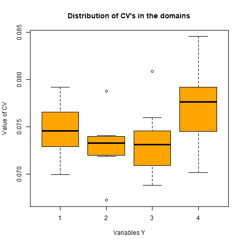

# Handling ‘take-all’ strata in the optimization step

As input to the optimization step, together with proper sampling strata, it is also possible to provide *take-all* strata. These strata will not be subject to optimisation as the proper strata, but they will contribute to the determination of the best stratification, as their presence in a given domain will permit to satisfy precision constraint with a lower number of units belonging to proper sampling strata.

In order to correctly execute the optimization and further steps, it is necessary to perform a pre-processing of the overall input. The first step to be executed consists in the bi-partition of units to be censused and of units to be sampled, in order to build two different frames:

```r
data(swisserrors)
data(swissstrata)
data(swissframe)
#----Selection of units to be censused from the frame
framecens <- swissframe[ (swissframe$domainvalue == 1 |
                          swissframe$domainvalue == 4) &
                         (swissframe$X2 == 1 &
                          swissframe$X3 == 1 &
                          swissframe$X4 == 1 &
                          swissframe$X5 == 1 &
                          swissframe$X6 == 1)  , ]
#----Selection of units to be sampled from the frame
# (complement to the previous)
framesamp <- swissframe[!((swissframe$domainvalue == 1 |
                           swissframe$domainvalue == 4) &
                          (swissframe$X2 == 1 &
                           swissframe$X3 == 1 &
                           swissframe$X4 == 1 &
                           swissframe$X5 == 1 &
                           swissframe$X6 == 1)) , ]
```

In this way, we have included all units belonging to ‘take-all’ strata in ‘framecens’, and the remaining in ‘framesamp’. At the end of the process, the sample will be selected from ‘framesamp’, while the units in ‘framecens’ will be simply added to the sample.

We can obtain census strata and sampling strata by applying *buildStrataDF* respectively to to *framecens* and *framesamp*:

```r
# Build strata to be censused and sampled
cens <- buildStrataDF(framecens,progress = FALSE)
```

```
#>
#> Computations are being done on population data
#>
#> Number of strata:  18
#> ... of which with only one unit:  2
```

```r
sum(cens$N)
```

```
#> [1] 405
```

```r
strata <- buildStrataDF(framesamp,progress = FALSE)
```

```
#>
#> Computations are being done on population data
#>
#> Number of strata:  623
#> ... of which with only one unit:  387
```

```r
sum(strata$N)
```

```
#> [1] 2491
```

and

```r
sum(cens$N)
```

```
#> [1] 405
```

```r
sum(strata$N)
```

```
#> [1] 2491
```

Now we have all required inputs to run ‘optimizeStrata’ in presence of the ‘take-all’ strata:

```r
solution <- optimizeStrata(
    errors = swisserrors,
    strata = strata,
    cens = cens,
    strcens = TRUE,
    parallel = FALSE,
    writeFiles = TRUE,
    showPlot = FALSE
)
```

```
#>
#>  *** Domain :  1   1
#>  Number of strata :  110
#> GA Settings
#>   Population size       = 20
#>   Number of Generations = 50
#>   Elitism               = 4
#>   Mutation Chance       = 0.00900900900900901
```

Once the optimized solution has been produced, the next steps are executed by considering only the sampling part of the frame:

```r
newstrata <- updateStrata(strata, solution)
# updating sampling frame with new strata labels
framenew <- updateFrame(frame=framesamp,newstrata=newstrata)
# selection of sample from sampling strata
sample <- selectSample(frame=framenew,outstrata=solution$aggr_strata)
```

```
#>
#> *** Sample has been drawn successfully ***
#>  205  units have been selected from  72  strata
#>
#> ==> There have been  12  take-all strata
#> from which have been selected  37 units
```

Finally, the units in the ‘take-all’ strata can be added to sampled ones. First, the census frame needs to be made homogeneous to the sample frame in order to permit the ‘rbind’ step:

```r
# addition of necessary variables to
colnames(framesamp) <- toupper(colnames(framesamp))
colnames(framecens) <- toupper(colnames(framecens))
framecens$WEIGHTS <- rep(1,nrow(framecens))
framecens$FPC <- rep(1,nrow(framecens))
framecens$LABEL <- rep("999999",nrow(framecens))
framecens$STRATUM <- rep("999999",nrow(framecens))
framecens$STRATO <- rep("999999",nrow(framecens))
```

The overall set of units to be surveyed is obtainable in this way:

```r
survey <- rbind(sample,framecens)
```

and this is the proportion of sampling and censused units:

```r
survey$cens <- ifelse(survey$LABEL == "999999",1,0)
table(survey$cens)
```

```
#>
#>   0   1
#> 205 405
```

# Handling Anticipated Variance

In the previous sections it has been assumed that, when optimizing the stratification of a sampling frame, values of the target variables Y’s are available for the generality of the units in the frame, or at least for a sample of them by means of which it is possible to estimate means and standard deviation of Y’s in atomic strata. Of course, this assumption is seldom expected to hold. The situation in which some proxy variables are available in the frame is much more likely to happen. In these situations, instead of directly indicating the real target variables, proxy ones are named as Y’s. By so doing, there is no guarantee that the final stratification and allocation can ensure the compliance to the set of precision constraints.  
In order to take into account this problem, and to limit the risk of overestimating the expected precision levels of the optimized solution, it is possible to carry out the optimization by considering, instead of the expected coefficients of variation related to proxy variables, the anticipated coefficients of variation (ACV) that depend on the model that is possile to fit on couples of real target variables and proxy ones. In the current implementation, only models linking continuous variables can be considered. The definition and the use of these models is the same that has been implemented in the package *stratification* (see Baillargeon and Rivest 2014). In particular, the reference here is to two different models, the linear model with heteroscedasticity:

$$Y=beta\times X + epsilon$$

where

$$epsilon \sim N(0,sig2 X^{gamma})$$

(in case gamma = 0, then the model is homoscedastic)

and the loglinear model:

$$Y= \exp (beta \times log(X) + epsilon)$$

where

$$epsilon \sim N(0,sig2)$$

In order to make evident the importance of the above, consider the following example, based on the dataset *nations* available in the package.

```r
data(nations)
head(nations)
```

```
#>          Country  TFR contraception infant.mortality   GDP  region
#> 1    Afghanistan 6.90            63              154  2848    Asia
#> 2        Albania 2.60            47               32   863  Europe
#> 3        Algeria 3.81            52               44  1531  Africa
#> 4 American-Samoa 1.35            71               11  2433 Oceania
#> 5        Andorra 1.61            71                7 19121  Europe
#> 6         Angola 6.69            19              124   355  Africa
#>   Continent
#> 1         2
#> 2         1
#> 3         4
#> 4         5
#> 5         1
#> 6         4
```

Let us assume that in the sampling frame only variable **GDP** (Gross Domestic Product) is available for all countries, while **contraception rates** and **infant mortality rates** are available only on a subset of countries (about one third).

```r
set.seed(1234)
nations_sample <- nations[sample(c(1:207),70),]
```

In this subset we can fit models between GDP and the two variables that we assume are the target of our survey.

One model for **infant mortality** and **GDP**:

```r
mod_logGDP_INFMORT <- lm(log(nations_sample$infant.mortality) ~ log(nations_sample$GDP))
summary(mod_logGDP_INFMORT)
```

```
#>
#> Call:
#> lm(formula = log(nations_sample$infant.mortality) ~ log(nations_sample$GDP))
#>
#> Residuals:
#>     Min      1Q  Median      3Q     Max
#> -1.1292 -0.3765 -0.1455  0.3316  2.6345
#>
#> Coefficients:
#>                         Estimate Std. Error t value             Pr(>|t|)
#> (Intercept)              6.86295    0.33620   20.41 < 0.0000000000000002
#> log(nations_sample$GDP) -0.46580    0.04389  -10.61 0.000000000000000452
#>
#> (Intercept)             ***
#> log(nations_sample$GDP) ***
#> ---
#> Signif. codes:  0 '***' 0.001 '**' 0.01 '*' 0.05 '.' 0.1 ' ' 1
#>
#> Residual standard error: 0.6158 on 68 degrees of freedom
#> Multiple R-squared:  0.6236, Adjusted R-squared:  0.6181
#> F-statistic: 112.7 on 1 and 68 DF,  p-value: 0.0000000000000004523
```

and one model for **contraception** and **GDP**:

```r
mod_logGDP_CONTRA <- lm(log(nations_sample$contraception) ~ log(nations_sample$GDP))
summary(mod_logGDP_CONTRA)
```

```
#>
#> Call:
#> lm(formula = log(nations_sample$contraception) ~ log(nations_sample$GDP))
#>
#> Residuals:
#>      Min       1Q   Median       3Q      Max
#> -1.96139 -0.27360 -0.01435  0.45058  1.25143
#>
#> Coefficients:
#>                         Estimate Std. Error t value         Pr(>|t|)
#> (Intercept)              0.98318    0.30538   3.220          0.00197 **
#> log(nations_sample$GDP)  0.34649    0.03986   8.692 0.00000000000122 ***
#> ---
#> Signif. codes:  0 '***' 0.001 '**' 0.01 '*' 0.05 '.' 0.1 ' ' 1
#>
#> Residual standard error: 0.5593 on 68 degrees of freedom
#> Multiple R-squared:  0.5263, Adjusted R-squared:  0.5193
#> F-statistic: 75.55 on 1 and 68 DF,  p-value: 0.000000000001217
```

We define the *sampling frame* in this way:

```r
nations$progr <- c(1:nrow(nations))
nations$dom <- 1
frame <- buildFrameDF(nations,
                      id="Country",
                      X="progr",
                      Y=c("GDP","GDP"),
                      domainvalue = "dom")
```

that is, we replicate twice the variable **GDP** because it will be used once for **infant mortality** and once for **contraception**.

We set 10% and 5% precision constraints on these two variables:

```r
cv <- as.data.frame(list(DOM=rep("DOM1",1),
                         CV1=rep(0.10,1),
                         CV2=rep(0.05,1),
                         domainvalue=c(1:1)
                    ))
cv
```

```
#>    DOM CV1  CV2 domainvalue
#> 1 DOM1 0.1 0.05           1
```

We build the strata without any assumption on the variability of the two target variables, and proceed in the optimization:

```r
strata1 <- buildStrataDF(frame, progress = FALSE)
```

```
#>
#> Computations are being done on population data
#>
#> Number of strata:  207
#> ... of which with only one unit:  207
```

```
#>
#> -----------------
#>  Kmeans solution
#> -----------------
#>  *** Domain:  1  ***
#>  Number of strata:  7
#>  Sample size     :  17
#>  *** Domain :  1   1
#>  Number of strata :  207
#> GA Settings
#>   Population size       = 20
#>   Number of Generations = 50
#>   Elitism               = 4
#>   Mutation Chance       = 0.00480769230769231
#>
#>
#> Suggestions
#>   1 = (5, 3, 3, 6, 6, 7, 5, 6, 7, 4, 2, 7, 2, 2, 2, 7, 6, 6, 5, 7, 6, 1, 7, 6, 1, 6, 5, 5, 7, 6, 2, 6, 7, 6, 1, 5, 7, 6, 2, 1, 3, 3, 6, 6, 6, 1, 2, 2, 4, 6, 4, 5, 7, 7, 5, 7, 6, 5, 1, 1, 1, 1, 7, 5, 6, 4, 5, 4, 7, 3, 6, 4, 6, 4, 6, 2, 5, 1, 7, 6, 6, 5, 1, 6, 5, 6, 7, 7, 2, 2, 2, 5, 6, 6, 5, 6, 7,…
```

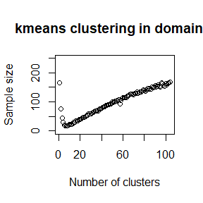

```r
solution1 <- optimizeStrata(cv,
                           strata1,
                           iter = 50,
                           pops = 20,
                           parallel = FALSE,
                           suggestions = KmeansSolution(strata1,cv),
                           writeFiles = TRUE,
                           showPlot = FALSE)
```

```r
sum(solution1$aggr_strata$SOLUZ)
```

```
#> [1] 16.62586
```

Then, we evaluate the expected CV’s on the three variables:

```r
newstrata <- updateStrata(strata1,solution1)
framenew1 <- updateFrame(frame,newstrata)
framenew1 <- framenew1[order(framenew1$ID),]
framenew1$Y2 <- nations$infant.mortality
framenew1$Y3 <- nations$contraception
results1 <- evalSolution(framenew1, solution1$aggr_strata, 50, progress = FALSE)
results1$coeff_var
```

```
#>          CV1       CV2       CV3  dom
#> 1 0.05332022 0.2326833 0.1431669 DOM1
```

Clearly, the CV’s on **infant mortality** and **contraception** are not compliant with the corresponding precision constraints.

We now proceed in building the **strata** dataframe using the models:

```r
model <- NULL
model$beta[1] <- mod_logGDP_INFMORT$coefficients[2]
model$sig2[1] <- summary(mod_logGDP_INFMORT)$sigma
model$type[1] <- "loglinear"
model$gamma[1] <- 0
model$beta[2] <- mod_logGDP_CONTRA$coefficients[2]
model$sig2[2] <- summary(mod_logGDP_CONTRA)$sigma
model$type[2] <- "loglinear"
model$gamma[2] <- 0
model <- as.data.frame(model)
model
```

```
#>         beta      sig2      type gamma
#> 1 -0.4658038 0.6157600 loglinear     0
#> 2  0.3464857 0.5593031 loglinear     0
```

```r
strata2 <- buildStrataDF(frame, model = model, progress = FALSE)
```

```
#>
#> Computations are being done on population data
#>
#> Number of strata:  207
#> ... of which with only one unit:  207
```

```r
head(strata2)
```

```
#>   STRATO N          M1        M2          S1        S2 COST CENS DOM1  X1
#> 1      1 1 0.024595860 15.737965 0.022690436 13.624506    1    0    1   1
#> 2     10 1 0.009910578 30.945032 0.009142812 26.789408    1    0    1  10
#> 3    100 1 0.011086660 28.468488 0.010227784 24.645441    1    0    1 100
#> 4    101 1 0.067027720  7.465936 0.061835128  6.463332    1    0    1 101
#> 5    102 1 0.064539738  7.678981 0.059539888  6.647767    1    0    1 102
#> 6    103 1 0.030744575 13.331076 0.028362814 11.540840    1    0    1 103
```

We proceed with the optimization

```r
strata2 <- buildStrataDF(frame, model = model, progress = FALSE)
```

```
#>
#> Computations are being done on population data
#>
#> Number of strata:  207
#> ... of which with only one unit:  207
```

```
#>
#> -----------------
#>  Kmeans solution
#> -----------------
#>  *** Domain:  1  ***
#>  Number of strata:  12
#>  Sample size     :  113
#>  *** Domain :  1   1
#>  Number of strata :  207
#> GA Settings
#>   Population size       = 20
#>   Number of Generations = 50
#>   Elitism               = 4
#>   Mutation Chance       = 0.00480769230769231
#>
#>
#> Suggestions
#>   1 = (12, 3, 3, 4, 4, 1, 12, 4, 9, 6, 8, 1, 8, 8, 8, 1, 7, 11, 6, 9, 7, 5, 1, 4, 5, 4, 12, 12, 1, 4, 8, 4, 9, 2, 5, 12, 1, 7, 8, 5, 3, 3, 4, 7, 10, 5, 8, 8, 6, 4, 6, 12, 9, 1, 12, 9, 7, 12, 5, 5, 3, 5, 1, 12, 7, 6, 12, 6, 9, 3, 2, 6, 10, 6, 7, 8, 12, 5, 9, 10, 11, 12, 3, 10, 12, 2, 9, 1, 8, 8, 8…
```

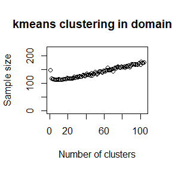

```r
solution2 <-
  optimizeStrata(
    errors = cv ,
    strata = strata2,
    iter = 50,
    pops = 20,
    parallel = FALSE,
    suggestions = KmeansSolution(strata2,cv),
    showPlot = FALSE,
    writeFiles = TRUE)
```

This time the sample size is much higher.

What about the expected CV’s?

```r
newstrata <- updateStrata(strata2,solution2)
framenew2 <- updateFrame(frame,newstrata)
framenew2 <- framenew2[order(framenew2$ID),]
framenew2$Y2 <- nations$infant.mortality
framenew2$Y3 <- nations$contraception
results2 <- evalSolution(framenew2, solution2$aggr_strata, 50, progress = FALSE)
results2$coeff_var
```

```
#>          CV1        CV2        CV3  dom
#> 1 0.00566401 0.05020429 0.02625483 DOM1
```

This time the expected CV’s of all variables are more than compliant with the precision constraints.

# Appendix - Methodological approach

In a stratified sampling design with one or more stages, a sample is selected from a frame containing the units of the population of interest, stratified according to the values of one or more auxiliary variables (X) available for all units in the population.

For a given stratification, the overall size of the sample and the allocation in the different strata can be determined on the basis of constraints placed on the expected accuracy of the various estimates regarding the survey variables (Y).

If the target survey variables are more than one the optimization problem is said to be **multivariate**; otherwise it is **univariate**.

The criteria according to which stratification is defined are crucial for the efficiency of the sample.

With the same precision constraints, the overall size of the sample required to satisfy them may be significantly affected by the particular stratification chosen for the population of interest.

Given G survey variables, their sampling variance is:

$$Var(\hat{Y_{g}})=\sum_{h=1}^{H}N_{h}^{2} (1- \frac{
n_{h}}
{N_{h}}) \frac{
S_{h,g}^{2}}
{n_{h}} \;\;\; g=1,...,G$$

If we introduce the following cost function:

$$C(n_{1},...,n_{H})=C_{0}+\sum_{h=1}^{H}C_{h}n_{h}$$

the optimization problem can be formalized in this way:

$$min= C_{0}+\sum_{h=1}^{H}C_{h}n_{h}\\$$
under the constraints
$$\begin{cases}
CV(\hat{Y_{1}}) < U_{1}\\
CV(\hat{Y_{2}}) < U_{2}\\
...\\
CV(\hat{Y_{G}}) < U_{G}\\
\end{cases}$$
where
$$CV(\hat{Y_{g}}) = \frac{\sqrt{Var(\hat{Y_{g}})} } {mean(\hat{Y_{g}})}$$

Given a population frame with m auxiliary variables $X_{1},..., X_{M}$ we define as **atomic stratification** the one that can be obtained considering the cartesian product of the definition domains of the m variables.
$$L=\{(l_{1}),(l_{2}),...,(l_{k})\}$$
Starting from the atomic stratification, it is possible to generate all the different stratifications that belong to the universe of stratifications. For example:

$$\begin{align*}
&P_{1}=\{(l_{1},l_{2},l_{3})\} & P_{2}=\{(l_{1}),(l_{2},l_{3})\} \\
&P_{2}=\{(l_{2}),(l_{1},l_{3})\} & P_{4}=\{(l_{31}),(l_{1},l_{2})\} \\
&P_{5}=\{(l_{1}),(l_{2}),(l_{k})\}
\end{align*}$$

The number of feasible stratifications is exponential with respect to the number of initial atomic strata:

$$\begin{align*}
& B_{4}=15 & B_{10}=115975 &
& B_{100}\approx 4.76 \times 10^{115}
\end{align*}$$

In concrete cases, it is therefore impossible to examine all the different possible alternative stratifications. The **Genetic Algorithm** allows to explore the universe of stratification in a very efficient way in order to find the optimal (or close to optimal) solution.

In planning a strafied sampling for a given survey, proceed as follows:

- given the survey variables $Y_{1},Y_{2},...,Y_{p}$, set **precision constraints** on their estimates in the different domains, expressed in terms of CVs (coefficients of variation);
- in the available sampling frame build the **atomic stratification**, obtained as cartesian product of the domains of the auxiliary variables $X_{1},...,X_{M}$;
- in each atomic stratum report the distributional characteristics of the survey variables by calculating their **means** and **standard deviations** calculate the values of the population (directly or by using proxy variables);
- on the basis of these inputs, the Genetic Algorithm determines the **best solution** in terms of both frame **stratification**, **sample size** and **allocation** in optimized strata.

The application of the genetic algorithm is based on the following steps:

- a given stratification is considered as an *individual* in a population (= *generation*) subject to *evolution*;
- each individual is characterized by a *genome* represented by a vector of dimension equal to the number of atomic strata: the position of each element in the vector identifies an atomic stratum;
- each element in the vector is assigned a random value between 1 and K (maximum acceptable number of strata): the vector therefore indicates the way in which the individual atomic strata are aggregated together;
- for each individual (stratification) its *fitness* is calculated by solving the corresponding problem of optimal allocation by means of Bethel’s algorithm;
- in passing from one generation to the next, *individuals with higher fitness are favored*;
- at the end of the process of evolution, *the individual with the overall best fitness represents the optimal solution*.

# References

Baillargeon, Sophie, and Louis-Paul Rivest. 2014. *Stratification: Univariate Stratification of Survey Populations*. https://CRAN.R-project.org/package=stratification.

Ballin, M., and G. Barcaroli. 2013. “Joint Determination of Optimal Stratification and Sample Allocation Using Genetic Algorithm.” *Survey Methodology* 39: 369–93.

Ballin, Marco, and Giulio Barcaroli. 2016. “Optimization of Stratified Sampling with the R Package SamplingStrata: Applications to Network Data.” *Computational Network Analysis with R: Applications in Biology, Medicine and Chemistry*. John Wiley & Sons.

Barcaroli, G. 2014. “SamplingStrata: An R Package for the Optimization of Stratified Sampling.” *Journal of Statistical Software* 61 (4): 1–24. http://www.jstatsoft.org/v61/i04/.

Hartigan, J. A., and M. A. Wong. 1979. “A K-Means Clustering Algorithm.” *Applied Statistics* 28: 100–108.

O’Luing, M., S. Prestwich, and S. Armagan Tarim. 2017. “Constructing Strata to Solve Sample Allocation Problems by Grouping Genetic Algorithm.” *arXiv:1709.03076*.

Willighagen, E. 2005. *Genalg: R Based Genetic Algorithm*. http://CRAN.R-project.org/package=genalg.